# Spiral Challenge

Write a program in the language of your choice that accepts a size as a program argument and draws a spiral of that size.

```
• Size = integer of the radius of the finished spiral.
• Each point should be a position on the spiral
• You an choose how to launch the program (command line or other)
• Best is if we can see a visual result.
• I'm looking for a circular spiral that covers all of the indices around 0, 0.
```

Please don’t use numpy or one of the existing math libraries to do the complete project if possible (of course, feel free to use trig functions and pi()). My interest is in understanding how you approached the problem and that you coded it yourself. See the picture at the end of this email for an example of how it should look when completed when displayed.

[figure not shown]

# Solution

The logarithmic spiral is a spiral whose polar equation is given by

\begin{align} r=ae^{b\theta} \end{align}

where r is the distance from the origin, theta is the angle from the x-axis, and a and b are arbitrary constants. The logarithmic spiral is also known as the growth spiral, equiangular spiral, and spira mirabilis. It can be expressed parametrically as:

\begin{align} x = rcos\theta = acos{\theta}e^{b\theta} \\ y = rsin\theta = asin{\theta}e^{b\theta} \end{align}

From the example above, the final point of the spiral is at angle \begin{align} 4\pi \end{align}

```python
import matplotlib.pyplot as plt
```

It's at the last angle that the radius is our function parameter so: \begin{align} size = rcos\theta = acos{\theta}e^{b\theta} \end{align}

To simplify, let's set b to -0.3 to get a similar direction than our example which gives us: \begin{align} size=ae^{-0.3*4\pi}  
\end{align}

And thus \begin{align} a=\frac{size}{e^{-0.3*4\pi}}  
\end{align}

```python
def draw_spiral(size):
    # Create the cartesian coordinates of the spiral from a series of angles
    max_angle = 4*math.pi
    step = max_angle/100
    a=size/math.exp(-0.3*4*math.pi)
    b=-0.3
    theta = 0
    x = []
    y = []
    fig, ax = plt.subplots()
    fig.set_size_inches(18.5, 10.5)
    while theta < max_angle:
        x.append(a*math.cos(theta)*math.exp(b*theta))
        y.append(a*math.sin(theta)*math.exp(b*theta))
        ax.plot(x, y)
        ax.set_aspect('equal')
        ax.grid(True, which='both')

        ax.axhline(y=0, color='k')
        ax.axvline(x=0, color='k')
        theta += step
    plt.show()
```

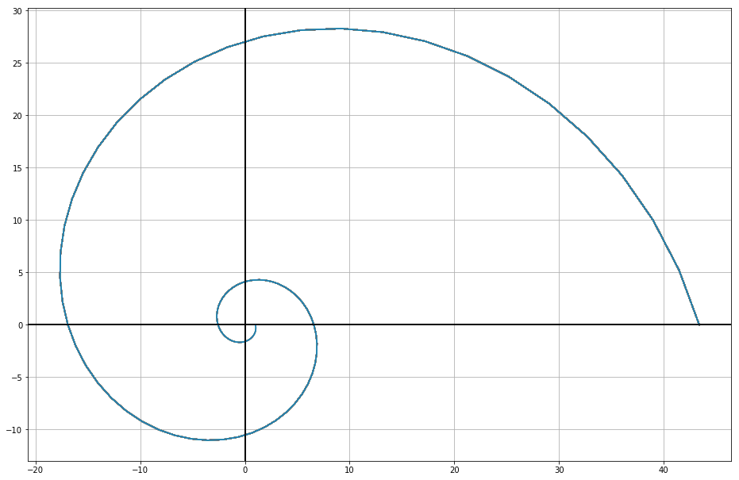

```python
draw_spiral(1)
```

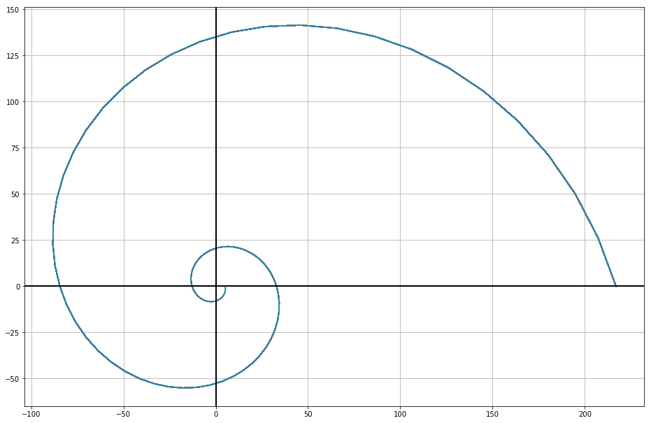

```python
draw_spiral(5)
```

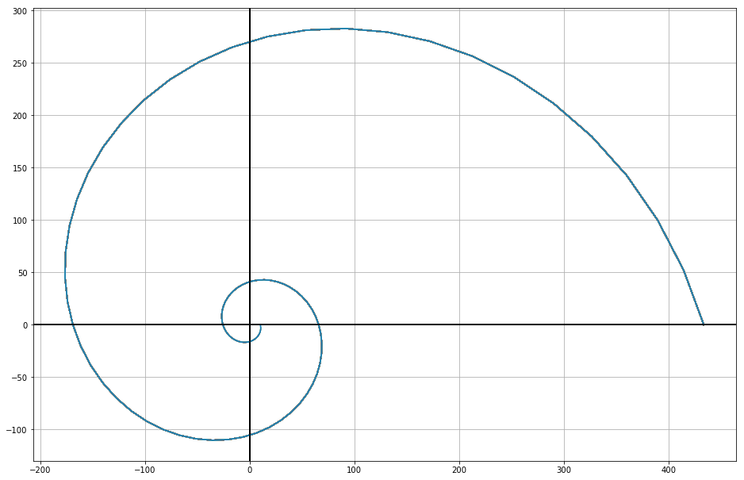

```python
draw_spiral(10)
```